# Counting dots on domino cards using OpenCV

```python
import cv2
import numpy as np
import matplotlib.pyplot as plt
from os import getcwd, listdir
from os.path import join
from get_frames import get_frames

%matplotlib inline
```

**First, prosses the input video to extract the images of the domino cards. We will use the function "get_frames" that is defined in the file "get_frames.py". This might take a few seconds.**

```python
cwd = getcwd()
images = get_frames()
print(images)
```

```
['f10.jpg', 'f85.jpg', 'f160.jpg', 'f235.jpg', 'f310.jpg', 'f385.jpg', 'f460.jpg', 'f535.jpg', 'f610.jpg']
```

**Now lets test a sample image**

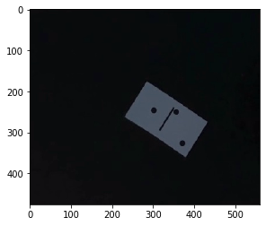

```python
img = cv2.imread(join(cwd, 'frames', images[7]))
plt.imshow(img)
```

**Great! Now we need to define a function to crop the domino card from the image**

```python
def find_dominoes(image):

    image_copy = image.copy()

    rgb = cv2.cvtColor(image_copy, cv2.COLOR_BGR2RGB)
    hsv = cv2.cvtColor(image_copy, cv2.COLOR_BGR2HSV)

    light_white = (0, 0, 40)
    dark_white = (200,200,255)

    mask_white = cv2.inRange(hsv, light_white, dark_white)
    result_white = cv2.bitwise_and(image_copy, image_copy, mask = mask_white)

    kernel = np.ones((3, 3), np.uint8)
    opened_1 = cv2.morphologyEx(mask_white, cv2.MORPH_OPEN, kernel,iterations = 2)
    opened_1 = cv2.dilate(opened_1, kernel, iterations = 15)
    opened_1 = cv2.morphologyEx(opened_1, cv2.MORPH_OPEN, kernel,iterations = 1)

    opened_2 = cv2.erode(opened_1, kernel, iterations = 3)
    opened_3 = cv2.dilate(opened_2, kernel, iterations = 5)
    mask = cv2.erode(opened_3, kernel, iterations = 20)

    contours, _ = cv2.findContours(opened_3,cv2.RETR_TREE,cv2.CHAIN_APPROX_SIMPLE)

    mask = np.zeros_like(image_copy) # Create mask where white is what we want, black otherwise
    cv2.drawContours(mask, contours, 0, 255, -1) # Draw filled contour in mask
    out = np.zeros_like(image_copy) # Extract out the object and place into output image
    out[mask == 255] = image_copy[mask == 255]

    # Now crop
    (y, x) = np.where(mask == 255)[0:2]
    (topy, topx) = (np.min(y), np.min(x))
    (bottomy, bottomx) = (np.max(y), np.max(x))
    out = image_copy[topy:bottomy+1, topx:bottomx+1]
    return out
```

**Lets test it!**

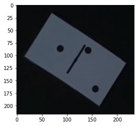

```python
cropped_img = find_dominoes(img)
plt.imshow(cropped_img)
```

**Now that we have croped the image, lets define a function to count the dots on the card. In order to do that we shall use the method of BLOB detection and tune the parameters with trial and error.**

```python
def get_shot_blob(image,
                  filter_by_area = True,
                  A = (1,150),
                  filter_by_color = True,
                  filter_by_circularity = True,
                  min_circularity = 0.8, # 0.8
                  filter_by_covexity = True,
                  min_convexity = 0.9, # 0.94
                  min_dist_between_blobs = 0,
                  filter_by_inertia = True,
                  min_inertia_ratio = 0.15 # 0.66
                 ):
    ## takes RGB image , returns centers of shots  by simple blob detector method
    image_copy = image.copy()
    img_Gray = cv2.cvtColor(image_copy, cv2.COLOR_RGB2GRAY)
    # Setup SimpleBlobDetector parameters
    params = cv2.SimpleBlobDetector_Params()

    # Change thresholds
    params.minThreshold = 0
    params.maxThreshold = 500

    # Filter by Area.
    if filter_by_area:
        params.filterByArea = filter_by_area
        params.minArea = A[0]
        params.maxArea = A[1]
    # Filter by Color.
    if filter_by_color:
        params.filterByColor = filter_by_color
        params.blobColor = 0

    # Filter by Circularity
    if filter_by_circularity:
        params.filterByCircularity = filter_by_circularity
        params.minCircularity = min_circularity

    # Filter by Convexity
    if filter_by_covexity:
        params.filterByConvexity = filter_by_covexity
        params.minConvexity = min_convexity

    params.minDistBetweenBlobs = min_dist_between_blobs

    # Filter by Inertia
    if filter_by_inertia:
        params.filterByInertia = filter_by_inertia
        params.minInertiaRatio = min_inertia_ratio

    # Create a detector with the parameters
    ver = (cv2.__version__).split('.')
    if int(ver[0]) < 3:
        detector = cv2.SimpleBlobDetector(params)
    else:
        detector = cv2.SimpleBlobDetector_create(params)

    im_with_keypoints = detector.detect(img_Gray)
#     print(len(im_with_keypoints))

    centers = []
    for key in im_with_keypoints:
        centers.append((int(key.pt[0]), int(key.pt[1])))

    # Highlight dots.
    for center in centers:
        output_image = cv2.circle(image_copy, center, 10,(0,255,0), -1)

    return output_image, centers
```

**Lets test it!**

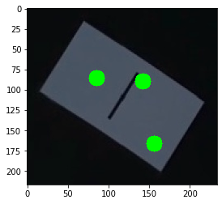

```python
output_image, centers = get_shot_blob(cropped_img,
                          filter_by_area = True,
                          A = (1,500),
                          filter_by_color = False,
                          filter_by_circularity = True,
                          min_circularity = 0.85,
                          filter_by_covexity = True,
                          min_convexity = 0.9,
                          min_dist_between_blobs = 0,
                          filter_by_inertia = False,
                          min_inertia_ratio = 0.15 # 0.66
                         )
plt.imshow(output_image)
```

**Pretty cool, hah? So far we croped the domino card and counted the dots on it. Now all we need is to find how many dots are on each half. That could be accomplished by the fillowing steps:**

```
- Find the slope of the line in the middle of the domino card
- count the dots on each side of that line
```

**Let's define a function to find the slope of the middle line!**

```python
def get_domino_slope(image):

    image_copy = image.copy()
    dst = cv2.Canny(image_copy, 0, 200, None, 3)
    linesP = cv2.HoughLinesP(dst, 1, np.pi / 180, 50, None, 50, 100)

    # Calculate lengthes of detected lines
    lengthes = []
    for x1,y1,x2,y2 in linesP[:, 0]:
        lengthes.append(((x1-x2)**2+(y1-y2)**2)**0.5)

    # Extract coordinates of the longest line
    x1,y1,x2,y2 = linesP[lengthes == max(lengthes),0][0]

    # Draw the longest line
    image_copy = image.copy()
    out = cv2.line(image_copy,(x1,y1),(x2,y2),(0,255,0),2)

    # Find the center of the longest line
    x_center = int((x1+x2)/2)
    y_center = int((y1+y2)/2)
    prep_point = (x_center, y_center)

    # Calculate the slope of the prependicular to the longest line
    slope = (y1-y2)/(x1-x2)
    slope_prep = -1/slope

    # Calculate another point on the prependicular line
    x_prep = 100
    y_prep = int(y_center + (slope_prep*(x_prep - x_center)))

    # Draw the prependicular line
    out = cv2.line(image_copy, (x_prep,y_prep), (x_center,y_center), (0,255,0), 2)
    out = cv2.circle(image_copy, (x_center,y_center), 10,(0,0,255), -1)
    out = cv2.circle(image_copy, (x_prep,y_prep), 10,(0,0,255), -1)

    return out, slope_prep, prep_point
```

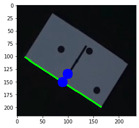

```python
lined_image, slope_prep, prep_point = get_domino_slope(cropped_img)
plt.imshow(lined_image)
```

**Awesome! Now that we calculated the slope of the middle line all what's left is to count the dots on each side of this line. Let's define a function to do that!**

```python
def count_dots(slope, point, centers):
    upper = 0
    lower = 0
    x_point = point[0]
    y_point = point[1]

    for center in centers:
        x = center[0]
        y = center[1]

        y_line = y_point + (slope*(x - x_point))
        if y > y_line:
            lower += 1
        else:
            upper += 1
    print(f'Number of dots: ({upper}, {lower})')
```

```python
count_dots(slope_prep, prep_point, centers)
```

```
Number of dots: (1, 2)
```

**Now that we have built all the required building blocks, let's loop through all images and count the dots on each one!**

```
Number of dots: (1, 1)
Number of dots: (6, 5)
Number of dots: (4, 4)
Number of dots: (4, 5)
Number of dots: (2, 6)
Number of dots: (6, 3)
Number of dots: (1, 3)
Number of dots: (1, 2)
Number of dots: (1, 2)
```

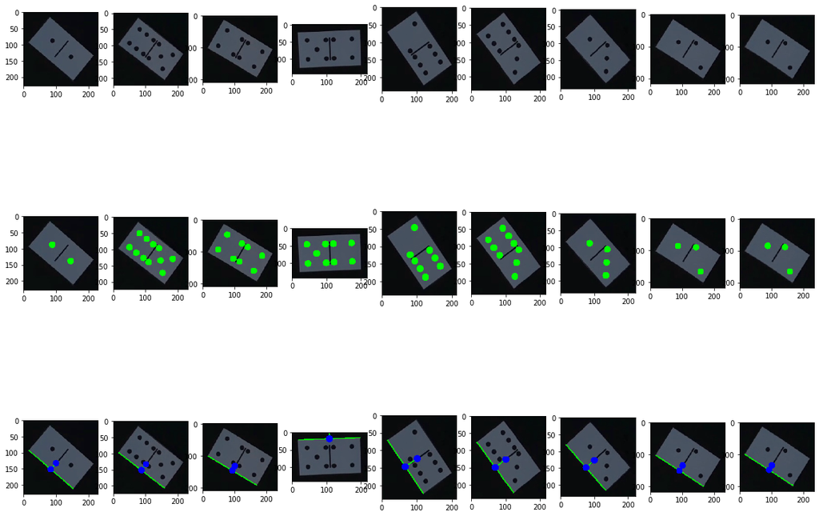

```python
num_images = len(images)

fig, axes = plt.subplots(3, num_images, figsize = [20, 15])

for i,img_name in enumerate(images):
    img = cv2.imread(join(cwd, 'frames', img_name))
    cropped_img = find_dominoes(img)
    plt.subplot(3, num_images, i+1)
    plt.imshow(cropped_img)

    dotted_img, centers = get_shot_blob(cropped_img,
                          filter_by_area = True,
                          A = (1,500),
                          filter_by_color = False,
                          filter_by_circularity = True,
                          min_circularity = 0.85,
                          filter_by_covexity = True,
                          min_convexity = 0.9,
                          min_dist_between_blobs = 0,
                          filter_by_inertia = False,
                          min_inertia_ratio = 0.15 # 0.66
                         )
    plt.subplot(3, num_images, i+1+num_images)
    plt.imshow(dotted_img)

    lined_img, slope_prep, prep_point = get_domino_slope(cropped_img)
    plt.subplot(3, num_images, i+1+2*num_images)
    plt.imshow(lined_img)

    count_dots(slope_prep, prep_point, centers)
```